DS 6030 | Fall 2023 | University of Virginia

# Homework #2: Resampling

Author

Jacqui Unciano

Published

September 13, 2023

# Required R packages and Directories

```r
data.dir = 'https://mdporter.github.io/DS6030/data/' # data directory
library(tidymodels)# for optional tidymodels solutions
library(tidyverse) # functions for data manipulation
library(FNN)
```

# Problem 1: Bootstrapping

Bootstrap resampling can be used to quantify the uncertainty in a fitted curve.

## a. Data Generating Process

Create a set of functions to generate data from the following distributions:
$$\begin{align*}
X &\sim \mathcal{U}(0, 2) \qquad \text{Uniform in $[0,2]$}\\
Y &= 1 + 2x + 5\sin(5x) + \epsilon \\
\epsilon &\sim \mathcal{N}(0,\, \sigma=2.5)
\end{align*}$$

**Solution**

```r
## uniform dist
x_vals = function(n){
  runif(n, min=0, max=2)
}
## function equation
func = function(x){
  1+(2*x)+(5*sin(5*x))
}
## y dist
y_vals = function(x, sd=2.5){
  n = length(x)
  func(x)+rnorm(n, sd=sd)
}
```

## b. Simulate data

Simulate $n=100$ realizations from these distributions. Produce a scatterplot and draw the true regression line $f(x) = E[Y \mid X=x]$. Use `set.seed(211)` prior to generating the data.

**Solution**

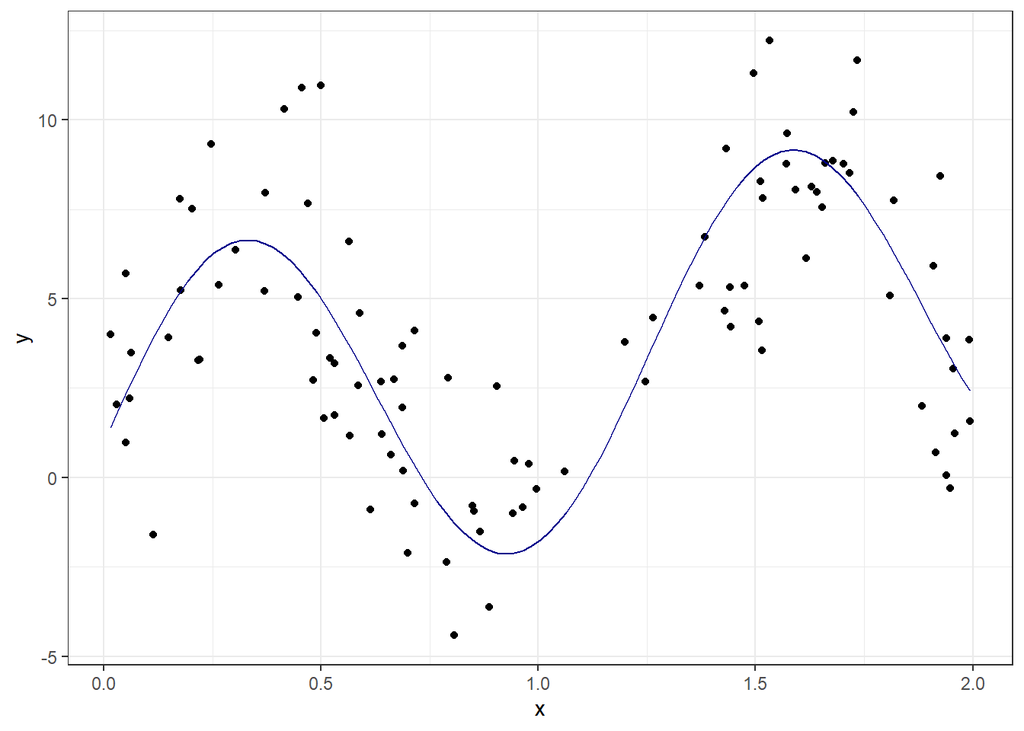

```r
set.seed(211)
n=100
x = x_vals(n)
y = y_vals(x)
data_train= tibble(x=x, y=y)
ggplot(data=data_train)+
  geom_point(aes(x=x, y=y))+
  geom_function(fun = func, color="darkblue")+
  theme_bw()
```

## c. 5th degree polynomial fit

Fit a 5th degree polynomial. Produce a scatterplot and draw the *estimated* regression curve.

**Solution**

```r
dg = tibble(x=seq(0,2,length=100))
```

```r
fifth = lm(y~poly(x, degree=5), data=data_train)
f = predict(fifth, dg)
```

```r
preds = dg %>%
  mutate(fifth=f)
```

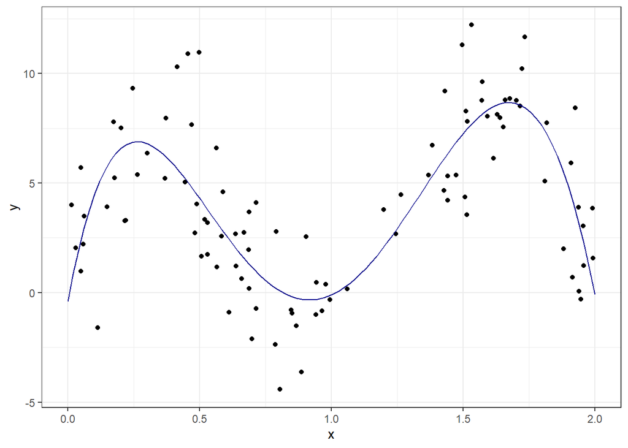

```r
ggplot(data_train)+
  geom_point(aes(x=x, y=y))+
  geom_line(data=preds, aes(x=x, y=fifth),
            color="darkblue")+
  theme_bw()
```

## d. Bootstrap sampling

Make 200 bootstrap samples. For each bootstrap sample, fit a 5th degree polynomial and make predictions at `eval_pts = seq(0, 2, length=100)`

- Set the seed (use `set.seed(212)`) so your results are reproducible.
- Produce a scatterplot with the original data and add the 200 bootstrap curves

**Solution**

```r
M = 200 # number of bootstrap samples
data_eval = tibble(x=seq(0, 2, length=100)) # evaluation points
YHAT = matrix(NA, nrow(data_eval), M) # initialize matrix for fitted values
set.seed(212)
for(m in 1:M){
  # sample indices/rows from empirical distribution (with replacement)
  ind = sample(100, replace=TRUE)
  m_boot = lm(y~poly(x, degree=5), data = data_train[ind,])
  # predict from bootstrap model
  YHAT[,m] = predict(m_boot, data_eval)
}
```

```r
#: Convert to tibble and plot
data_fit = as_tibble(YHAT) %>% # convert matrix to tibble
  bind_cols(data_eval) %>% # add the eval points
  pivot_longer(-x, names_to="simulation", values_to="y") # convert to long format
```

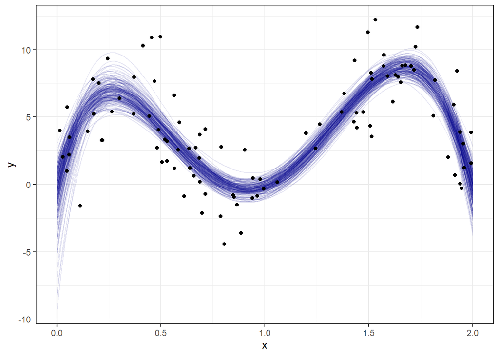

```r
ggplot(data_train, aes(x,y))+
  geom_line(data=data_fit, color="darkblue", alpha=.1, aes(group=simulation))+
  geom_point()+
  theme_bw()
```

## e. Confidence Intervals

Calculate the pointwise 95% confidence intervals from the bootstrap samples. That is, for each $x \in {\rm eval\_pts}$, calculate the upper and lower limits such that only 5% of the curves fall outside the interval at $x$.

- Remake the plot from part *c*, but add the upper and lower boundaries from the 95% confidence intervals.

**Solution**

```r
lb = apply(YHAT, 1, function(row) quantile(row, 0.025))
ub = apply(YHAT, 1, function(row) quantile(row, 0.975))
ci = tibble(x=data_eval, lower=lb, upper=ub)
```

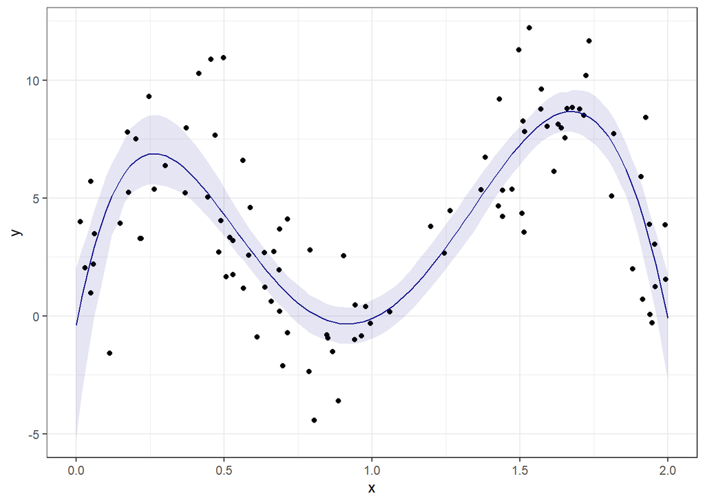

```r
ggplot()+
  geom_point(data=data_train, aes(x=x, y=y))+
  geom_line(data=preds, aes(x=x, y=fifth),
            color="darkblue")+
  labs(color="")+
  guides(color=guide_legend(title="Regression Models"))+
  geom_ribbon(data=ci, aes(x=x$x, ymin=lower, ymax=upper),
              fill="darkblue",
              alpha=0.1)+
  theme_bw()
```

# Problem 2: V-Fold cross-validation with $k$ nearest neighbors

Run 10-fold cross-validation on the data generated in part 1b to select the optimal $k$ in a k-nearest neighbor (kNN) model. Then evaluate how well cross-validation performed by evaluating the performance on a large test set. The steps below will guide you.

## a. Implement 10-fold cross-validation

Use $10$-fold cross-validation to find the value of $k$ (i.e., neighborhood size) that provides the smallest cross-validated MSE using a kNN model.

- Search over $k=3,4,\ldots, 40$.
- Use `set.seed(221)` prior to generating the folds to ensure the results are replicable.
- Show the following:
  - the optimal $k$ (as determined by cross-validation)
  - the corresponding estimated MSE
  - produce a plot with $k$ on the x-axis and the estimated MSE on the y-axis (optional: add 1-standard error bars).
- Notation: The $k$ is the tuning paramter for the kNN model. The $v=10$ is the number of folds in V-fold cross-validation. Don’t get yourself confused.

**Solution**

```r
#: Function to evaluate kNN
knn_eval = function(k, data_train, data_test){
  # fit model and eval on training data
  knn = knn.reg(data_train[,'x', drop=FALSE],
  y = data_train$y,
  test = data_train[,'x', drop=FALSE],
  k = k)
  r = data_train$y-knn$pred # residuals on training data
  mse.train = mean(r^2) # training MSE
  # fit model and eval on test data
  knn.test = knn.reg(data_train[,'x', drop=FALSE],
                     y = data_train$y,
                     test=data_test[,'x', drop=FALSE],
                     k=k)
  r.test = data_test$y-knn.test$pred # residuals on test data
  mse.test = mean(r.test^2) # test MSE
  # results
  edf = nrow(data_train)/k # effective dof (edof)
  tibble(k=k, edf=edf, mse.train, mse.test)
}
```

```r
#- Get K-fold partition
n.folds = 10 # number of folds for cross-validation
n=100
k = seq(3,40,1)
set.seed(221) # set seed for reproducibility
fold = sample(rep(1:n.folds, length=n)) # vector of fold labels
# notice how this is different than: sample(1:K,n,replace=TRUE),
# which won't necessarily give almost equal group sizes
results = vector("list", n.folds)
#- Iterate over folds
for(j in 1:n.folds){
  #-- Set training/val data
  val = which(fold == j) # indices of holdout/validation data
  train = which(fold != j) # indices of fitting/training data
  n.val = length(val) # number of observations in validation

    #- fit and evaluate models
  results[[j]] = map_df(k,
                        knn_eval,
                        data_train = slice(data_train, train),
                        data_test = slice(data_train, val)) %>%
    mutate(fold = j, n.val) # add fold number and number in validation)
}

RESULTS = bind_rows(results)
```

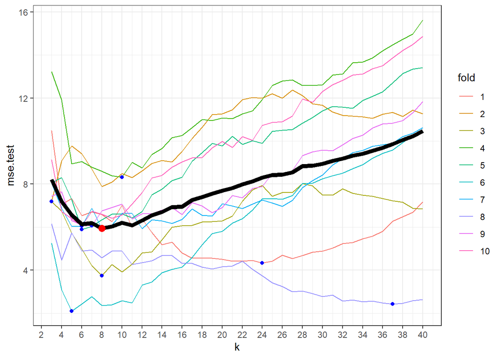

```r
RESULTS %>%
  mutate(fold = factor(fold)) %>%
  ggplot(aes(k, mse.test)) +
  geom_line(aes(color=fold)) +
  geom_point(data=. %>% group_by(fold) %>% slice_min(mse.test, n=1), color="blue") +
  geom_line(data = . %>% group_by(k) %>% summarize(mse.test = mean(mse.test)), linewidth=2) +
  geom_point(data = . %>% group_by(k) %>% summarize(mse.test = mean(mse.test)) %>%
               slice_min(mse.test, n=1), size=3, color="red") +
  scale_x_continuous(breaks = seq(0, 40, by=2)) +
  theme_bw()
```

## b. Find the optimal *edf*

The $k$ (number of neighbors) in a kNN model determines the effective degrees of freedom *edf*. What is the optimal *edf*? Be sure to use the correct sample size when making this calculation. Produce a plot similar to that from part *a*, but use *edf* (effective degrees of freedom) on the x-axis.

**Solution**

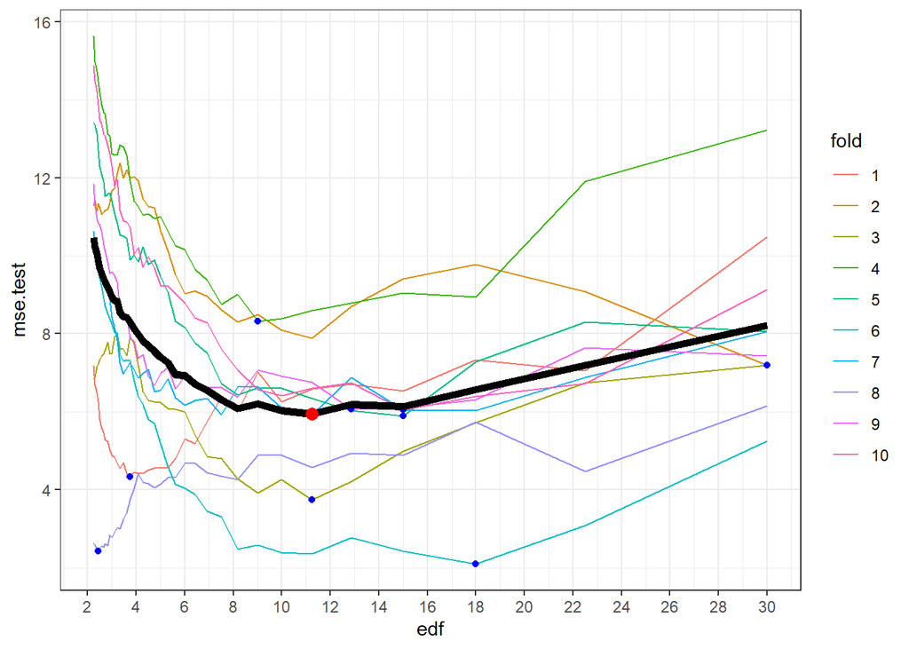

```r
RESULTS %>%
  mutate(fold = factor(fold)) %>%
  ggplot(aes(edf, mse.test)) +
  geom_line(aes(color=fold)) +
  geom_point(data=. %>% group_by(fold) %>% slice_min(mse.test, n=1), color="blue") +
  geom_line(data = . %>% group_by(edf) %>% summarize(mse.test = mean(mse.test)), linewidth=2) +
  geom_point(data = . %>% group_by(edf) %>% summarize(mse.test = mean(mse.test)) %>%
               slice_min(mse.test, n=1), size=3, color="red") +
  scale_x_continuous(breaks = seq(0, 40, by=2)) +
  theme_bw()
```

## c. Choose $k$

After running cross-validation, a final model fit from *all* of the training data needs to be produced to make predictions. What value of $k$ would you choose? Why?

**Solution**

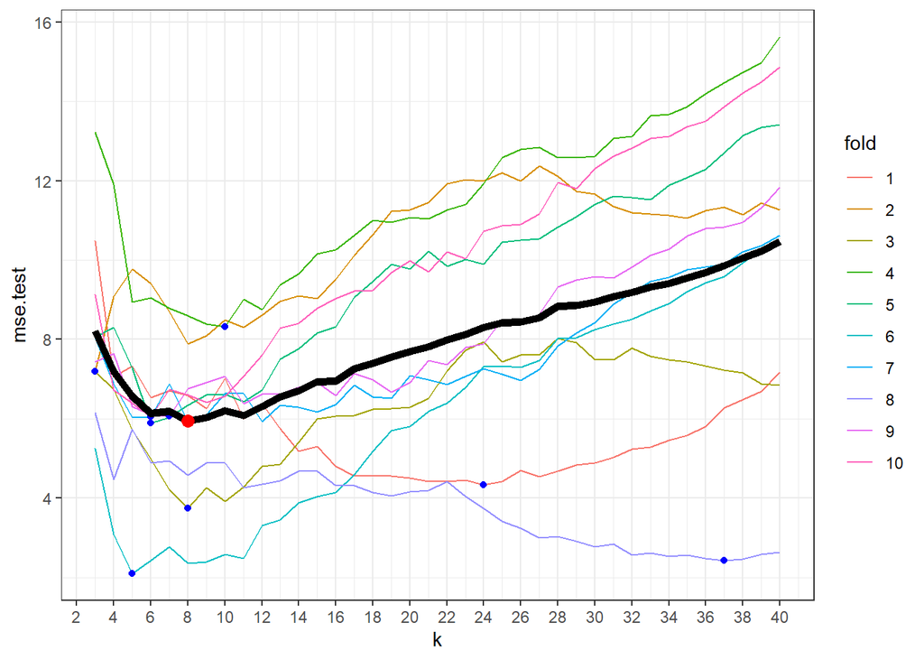

```r
RESULTS %>%
  mutate(fold = factor(fold)) %>%
  ggplot(aes(k, mse.test)) +
  geom_line(aes(color=fold)) +
  geom_point(data=. %>% group_by(fold) %>% slice_min(mse.test, n=1), color="blue") +
  geom_line(data = . %>% group_by(k) %>% summarize(mse.test = mean(mse.test)), linewidth=2) +
  geom_point(data = . %>% group_by(k) %>% summarize(mse.test = mean(mse.test)) %>%
               slice_min(mse.test, n=1), size=3, color="red") +
  scale_x_continuous(breaks = seq(0, 40, by=2)) +
  theme_bw()
```

I would choose a k between 7 and 8 because the MSE seems to be the lowest around there for most of the tests.

## d. Evaluate actual performance

Now we will see how well cross-validation performed. Simulate a test data set of $50000$ observations from the same distributions. Use `set.seed(223)` prior to generating the test data.

- Fit a set of kNN models, using the full training data, and calculate the mean squared error (MSE) on the test data for each model. Use the same $k$ values in *a*.
- Report the optimal $k$, the corresponding *edf*, and MSE based on the test set.

**Solution**

```r
set.seed(223)
n=50000
x = x_vals(n)
y = y_vals(x)
data_test = tibble(x=x, y=y)
```

```r
k = seq(3,40,1)
RESULTS2 = map_df(k, knn_eval, data_train = data_train, data_test = data_test)
RESULTS2
```

```
# A tibble: 38 × 4
      k   edf mse.train mse.test
  <dbl> <dbl>     <dbl>    <dbl>
1     3  33.3      3.91     7.91
2     4  25        4.54     7.57
3     5  20        4.51     7.42
4     6  16.7      4.70     7.30
5     7  14.3      4.71     7.26
6     8  12.5      4.80     7.14
# ℹ 32 more rows
```

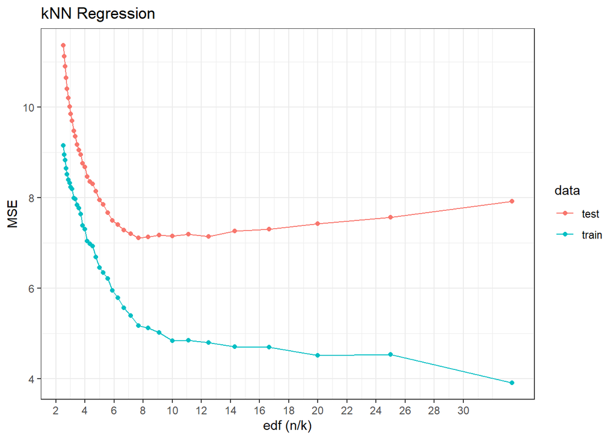

```r
#: Plot Results
RESULTS2 %>%
  # make long:
  pivot_longer(starts_with("mse"), names_to="data", values_to="mse") %>%
  # remove 'mse.' from values:
  mutate(data = str_remove(data, "mse\\.")) %>%
  # plot:
  ggplot(aes(edf, mse, color=data))+
  geom_line()+
  geom_point()+
  labs(title="kNN Regression", x='edf (n/k)', y="MSE")+
  scale_x_continuous(breaks=seq(2, 30, by=2))+
  theme_bw()
```

```r
RESULTS2 %>%
  filter(mse.test==min(mse.test))
```

```
# A tibble: 1 × 4
      k   edf mse.train mse.test
  <dbl> <dbl>     <dbl>    <dbl>
1    13  7.69      5.17     7.11
```

The model with the optimal MSE (the lowest MSE: 7.11) has a k value of 13 and an edf of around 7.69.

## e. Performance plots

Plot both the cross-validation estimated and (true) error calculated from the test data on the same plot. See Figure 5.6 in ISL (pg 182) as a guide.

- Produce two plots: one with $k$ on the x-axis and one with *edf* on the x-axis.
- Each plot should have two lines: one from part *a* and one from part *d*

**Solution**

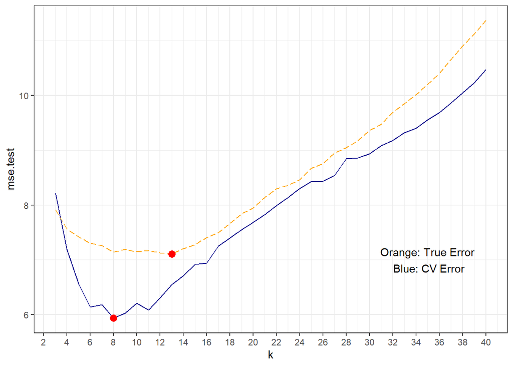

```r
ggplot()+
  geom_line(data = RESULTS %>% group_by(k) %>% summarize(mse.test = mean(mse.test)),
            aes(k, mse.test),
            color="darkblue")+
  geom_point(data = RESULTS %>% group_by(k) %>% summarize(mse.test = mean(mse.test)) %>%
               slice_min(mse.test, n=1), aes(k, mse.test), size=3, color="red")+
  geom_line(data = RESULTS2, aes(k, mse.test), color="orange", linetype="longdash")+
  geom_point(data = RESULTS2 %>% filter(mse.test==min(mse.test)), aes(k, mse.test), size=3, color="red")+
  scale_x_continuous(breaks=seq(2, 40, by=2))+
  annotate ("text",x = 35,y = 7,label = "Orange: True Error\n Blue: CV Error")+
  theme_bw()
```

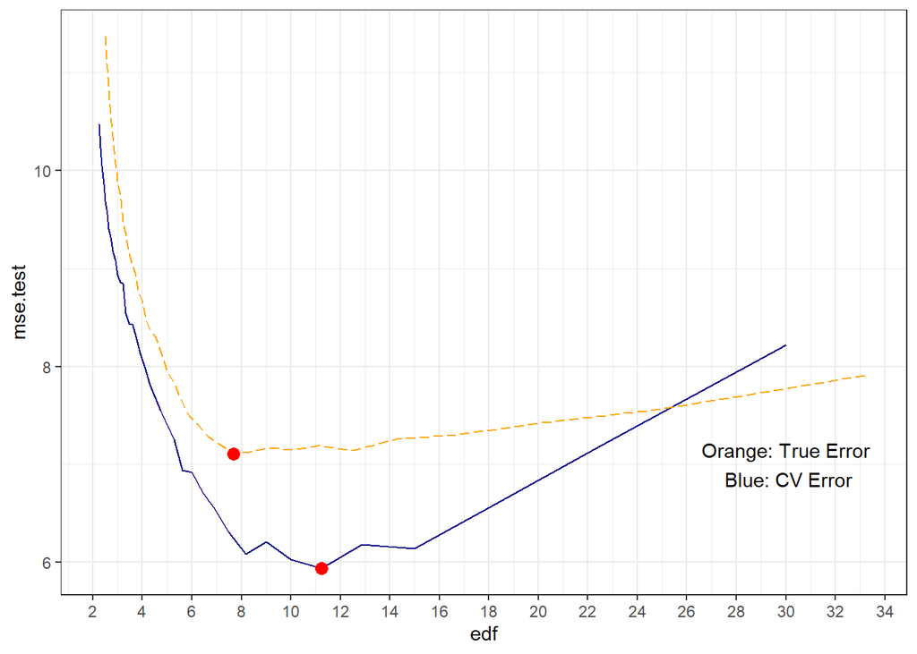

```r
ggplot()+
  geom_line(data = RESULTS %>% group_by(edf) %>% summarize(mse.test = mean(mse.test)),
            aes(edf, mse.test),
            color="darkblue")+
  geom_point(data = RESULTS %>% group_by(edf) %>% summarize(mse.test = mean(mse.test)) %>%
               slice_min(mse.test, n=1), aes(edf, mse.test), size=3, color="red")+
  geom_line(data = RESULTS2, aes(edf, mse.test), color="orange", linetype="longdash")+
  geom_point(data = RESULTS2 %>% filter(mse.test==min(mse.test)), aes(edf, mse.test), size=3, color="red")+
  scale_x_continuous(breaks=seq(2, 40, by=2))+
  annotate ("text",x = 30,y = 7,label = "Orange: True Error\n Blue: CV Error")+
  theme_bw()
```

## f. Did cross-validation work as intended?

Based on the plots from *e*, does it appear that cross-validation worked as intended? How sensitive is the choice of $k$ on the resulting test MSE?

**Solution**

NO, it doesn’t seem to have worked as intended. The CV seems to be really optimistic in MSE compared to the true MSE because the sample size is small. However, the choice of k on the true MSE is less sensitive than on the CV MSE because the differences between the MSE aren’t that large (8 and 13 as opposed to 8 and 20 or something) and the MSE is larger for the true error than the CV error.